# DATA-413/613 Homework: Shiny

Author

# Instructions

1. Clone the assignment repo to your homework directory as a new repo.
2. Review the provided assignment HTML file for detailed instructions, the rubric, and any images to be replicated.
3. Use the starter app.R file in the repo to build your app in accordance with the requirements below.
- This is a working app with a template of comments and other code. The other code creates a layout and the comments provide guidance/hints for where to put your code.
- **Do not change the code outside the indicated areas.** If you make a mistake and change it, the copy of the starter app can help you restore the templated code.
- You can un-comment some of the commented lines of code to enter your code or leave them in as comments.
- They provide a guide as to how the logic of your app could flow.
4. Push to GitHub after each main element.
5. Check your output to ensure all images are present and there is no excessive data being shown.
6. Once satisfied the assignment is complete, stage, commit, and push to GitHub.

**Submission Instructions when Assignment is complete and pushed to GitHub**

1. Click “Start Assignment.”
2. Enter the phrase: “Assignment is completed, rendered, pushed to GitHub and ready for evaluation.”
3. Click “Submit Assignment.

Use Pull requests and or email to ask me any questions. If you email, please ensure your most recent code is pushed to GitHub.

# Learning Outcomes

- Create Shiny Apps with basic inputs and outputs that connect together to support numerical and graphical analysis.
- Incorporate graphical outputs and statistical tests into an interactive app.

## Grading Criteria/Rubric

[output not shown]

# 1 Washington, DC Building Energy Performance

## 1.1 Introduction and Background on the Data

The city of Washington, DC Department of Energy & Environment (DOEE) collects data on public and private building energy performance disclosed under the Building Energy Performance Standards (BEPS) Program. This assignment uses a subset of that data downloaded in from [DC Open data](https://opendata.dc.gov/datasets/DCGIS::building-energy-performance/about). The subset has been filtered to produce a cleaner data set. Some variables have also been renamed.

The data set has ~14K rows. It has some issues due to how people report or don’t report correctly. You may get what look like strange results at times but the point is to allow someone to look at a lot of data quickly to identify potential relationships or issues.

The data is in the `energy_year.rds` file in the `data` folder of the sample app. Do not move the data. Use a relative path to load it in your business logic section.

- Summary of the data elements is at the end. To see more details about the data go to the DC Open data page for the data and select [View All Metadata](https://opendata.dc.gov/datasets/DCGIS::building-energy-performance/about) near the bottom right of the page.

## 1.2 Build a Basic Shiny App to Enable Exploratory Data Analysis

Use the starter app.R file in the repo to build your app.

The app should meet the requirements below:

### 1.2.1 Business Logic

1. Use a relative path to load the rds file of data.
2. Use tidyverse functions to transform the data so `Ward`, `Report_Year`, `Type_SS`, `Type_EPA`, `Metered_Energy` and `Metered_Water` are factors.
3. Use tidyverse functions to create a new factor variable called `Era` which has the following levels (in order) based on the values for `Built` and it is placed after `Built` in the data frame.
- Built < 1900 “Pre-1900”,
- Built < 1951 “Early-Mid 20th”,
- Built < 2000 “Late 20th”,
- Built < 2011 “Aughts”,
- otherwise “Teens and later”
4. Create a named function with two arguments, a vector of numeric data and a null value($\mu$). The function should run a t.test on the input vector of data to test if the mean is equal to the Null value. It should provide a tibble of output with five values:
- The estimate.
- The Null Value, $\mu$.
- The $p$-value.
- The lower bound of a 95% Confidence Interval.
- The upper bound of a 95% Confidence Interval.

Consider using `broom::tidy()`.

### 1.2.2 User Interface Section

There are input elements to support creating a plot of a single variable, a t-test, a plot of two variables, and the output from a linear model of the two variables in the plot.

Create User Interface input elements to allow the user to:

- Select a variable of interest from the data frame.The initial value should be `Energy_Star_Score`
- Select from a check box Group one or more Report years of interest. Set the initial selected value to only 2022.
- Choose whether to flip the coordinates for a factor variable.
- Choose whether to log transform the axis of the plot and log the data for the t-test.
- Select the number of bins in a histogram with a range from 1 to 100 with an initial value of 40.
- The null value for true population mean for a one-sample t-test with a minimum of 0 and a maximum of the maximum value of `Electricity_Grid_Usage`.
- For the bivariate plot, select the variable of interest for the X axis.
- Choose whether to log transform the variable for the X axis.
- Select the variable of interest for the Y axis.
- Choose whether to log transform the variable for the Y axis.
- Choose whether to add a linear model smoother line, with the argument `se=FALSE`.

Create User Interface output elements to show:

- A single variable plot.
- A table of t-test results.
- A bivariate plot (with or without a linear smoother line).
- A summary of linear model results.
- An interactive data table with all of the data.

## 1.3 Server Section

- Enter code following the guides in the starter file so the inputs connect to the outputs and generate correct results.
- A histogram if the variable is numeric and a barplot otherwise.
- Flipped coordinates for a factor if selected.
- A faceted plot *for each year selected*, i.e., facet on `year`.
- A log scale on the plot if log_transform is selected.
- The results of the one-sample t-test. The results of the test should be in accordance with the user’s choice of a log transformation (or not) for the data. Ensure the input variable is numeric.
  - Note: to test your results, enter a null value close to the estimate in your running app, else the $p$ value will be 0.
- If both variables are numeric for the bivariate plot, a scatter plot.
  - Indicate each year that is selected by color
- If one is numeric and one is categorical, a boxplot.
- If both variables are categorical, a jitter plot.
- Add a log scale for either axis or both if variable’s log transform is selected.
- Add a single linear smoother if the OLS line is selected.
- The linear model summary should consider whether either or both of the variables should be logged.
- An interactive data table to allow one to look at all of the data, sort it, and filter it. Limit the page length to 20 rows.
- **You do not need to add error checking. It is okay if certain selections of variables produce an error as long as the correct selection of variables does not.**

Your initial screen should look as close to the following as possible.

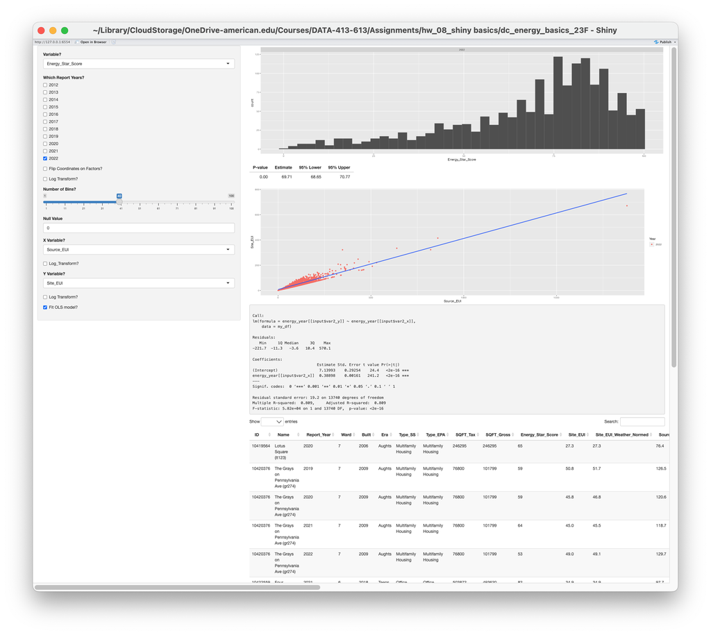

Initial App View

One possible view is as follows.

[figure not shown]

Possible App View

## 1.4 Suggestions

- Take advantage of the modularity built into {ggplot2} in conjunction with if-else statements to ensure you are tracking the variables types and whether the data has been asked to be logged. Write out your logic flow to ensure you have all cases covered without duplicating a lot of code. Consider the following example.

```r
# Create base plot
pl <- ggplot(mtcars, aes(x = disp, y = mpg))
# add geoms
    if (...) {
      pl <- pl + geom_point()
    } else if (...) {
      pl <- pl + geom_bar
    } else {
      pl <- pl + geom_jitter()
    }
    pl
```

- **Review the discussion about using variables selected from data frames in non-tidyverse functions, e.g., `is.numeric()`, `t.test()`, `lm()`, in the [lecture notes](https://rressler.quarto.pub/data-413-613/10_shiny_basics_main.html#identifying-varselectinput-data-frame-variables-in-base-r-functions).**
- **Use the RStudio Debug environment by inserting breakpoints in the Business Logic or Server Section code. If the breakpoints are not working for you, insert a `browser()` function inside the function that is causing trouble so you can check the values while running. Be sure to delete it when finished.**
- **Build a little, test a little**.
- Ask Questions!

## 1.5 Data Structure

| Variable | Definition |
| --- | --- |
| ID | ID number from Portfolio Manager—this serves as the unique key for each record. |
| Name | Name of property as reported by owner |
| Report_Year | Last Day of Reporting Year |
| Ward | Ward as recorded by the DC Office of Tax and Revenue |
| Built | The year property was constructed |
| Type_SS | The Primary Use of the Property, as self-selected by owner. |
| Type_EPA | The Primary Use of the Property, as calculated by EPA Portfolio Manager |
| SQFT_Tax | The Gross Floor Area as recorded by the DC Office of Tax and Revenue in square feet |
| SQFT_Gross | The Gross Floor Area as reported by owner, in square feet. The Gross Floor Area is the total size, as measured between the principal exterior surfaces of the enclosing fixed walls of the building(s). … |
| Energy_Star_Score | The 1‐100 score calculated by ENERGY STAR Portfolio Manager® that measures how well the property is performing relative to similar properties, when normalized for climate and operational characteristi… |
| Site_EUI | The Site Energy Use Intensity (EUI), as calculated by Portfolio Manager, at the property site. This equals the amount of energy consumed at the site in thousand British thermal units (kBtus) per gross… |
| Site_EUI_Weather_Normed | Weather normalized Site Energy Use Intensity is the Site EUI in kBtu/ft2 of the property, normalized for weather. Weather normalization facilitates the comparison between different parts of the countr… |
| Source_EUI | Source Energy Use divided by property square footage, normalized for weather. Weather‐normalization is based on National Oceanic and Atmospheric Administration (NOAA) weather data for the zip code. |
| Source_EUI_Weather_Normed | Source EUI (kBtu/ft2) of the property, normalized for weather. Weather normalization facilitates comparison between different parts of the country and corrects for year-to‐year differences in weather. |
| GH_Gas | Greenhouse Gas (GHG) Emissions are expressed in Metric Tons of carbon dioxide equivalent (CO2e). Total Emissions is the sum of Direct Emissions (emissions associated with onsite fuel combustion) and I… |
| GH_Gas_Intensity | The total Greenhouse Gas (GHG) Emissions, divided by the floor area of the building, in kilograms of carbon dioxide equivalent (CO2e) per square foot. |
| Water_Score | EPA’s 1-100 Water Score for Multifamily Housing, is a measure of how efficiently your property is using water, compared to similar properties, when normalized for climate and operational characteristi… |
| Water_Usage | Total annual water consumption in kilogallons (1,000 gallons). |
| Natural_Gas_Usage | The total annual natural gas consumed by the property. |
| Fuel_Oil_Diesel_Usage | Total annual energy consumption from liquid fuel use on the property. |
| Metered_Energy | The portions of the building for which energy use was reported |
| Metered_Water | The portions of the building for which water use was reported, according to EPA. (Note that water data is almost always metered at the whole building level in DC, so a blank value here is usually not … |
| Dist_Chilled_Water_Usage | Total annual energy consumption from District Chilled Water. |
| Dist_Hot_Water_Usage | Total annual energy consumption from District Hot Water. |
| Dist_Steam_Usage | Total annual energy consumption from District Steam systems |
| Electricity_Renewable_Usage | The total annual electricity consumed by the property generated and used onsite from any onsite renewable energy generation systems |
| Electricity_Grid_Usage | The total annual electricity consumed by the property sourced from the electrical grid. |
| Latitude | Geographic coordinate that specifies the north–south position of a point on the Earth’s surface |
| Longitude | Geographic coordinate that specifies the east‐west position of a point on the Earth’s surface |

Per EPA on [Source vs Site](https://www.energystar.gov/buildings/benchmark/understand_metrics/source_site_difference) source energy is the most equitable unit of evaluation for comparing different buildings to each other. Source energy represents the total amount of raw fuel that is required to operate the building. It incorporates all transmission, delivery, and production losses. By taking all energy use into account, the score provides a complete assessment of energy efficiency in a building. Site energy is the amount of heat and electricity consumed by a building as reflected in your utility bills. Looking at site energy can help you understand how the energy use for an individual building has changed over time.